# DA410_Assignment6_MattGraham

Finding canonical correlationss

```r
library(nnspat)  # used for dist2full()
library("dplyr")  # used to select numeric datatypes
library("ggplot2")
library(reshape)  # used for melting matricies
library(klaR)
library(ggvis)
library(class)
library(gmodels)
library(MASS)
library(readxl)
library(psych)
```

Determines set of canonical varirates that are orthogonal linear combinations that best explain variabilities within and between sets. It is common to have multiple canonical variables.

## 11.9

### a

Get data

```r
sons <- read.table("C:/mattgraham93.github.io/school/22_3_DA410/data/T3_8_SONS.DAT", header=FALSE)
colnames(sons) <- c('fs_hl', 'fs_hb', 'ss_hl', 'ss_hb')  ## hl = head length, hb = head breadth, fs = first son, ss = second son
sons
```

| fs_hl | fs_hb | ss_hl | ss_hb |
| --- | --- | --- | --- |
| 191 | 155 | 179 | 145 |
| 195 | 149 | 201 | 152 |
| 181 | 148 | 185 | 149 |
| 183 | 153 | 188 | 149 |
| 176 | 144 | 171 | 142 |
| 208 | 157 | 192 | 152 |
| 189 | 150 | 190 | 149 |
| 197 | 159 | 189 | 152 |
| 188 | 152 | 197 | 159 |
| 192 | 150 | 187 | 151 |

[output cut: 15 more lines]

Standardize variables and assign measure groups

```r
sons.std <- sweep(sons, 2, sqrt(apply(sons, 2, var)), FUN="/")

y.meas <- sons.std[, 1:2] ## first son
x.meas <- sons.std[, 3:4] ## second son

sons.std
```

| fs_hl | fs_hb | ss_hl | ss_hb |
| --- | --- | --- | --- |
| 19.56600 | 21.02287 | 17.82824 | 21.60972 |
| 19.97576 | 20.20908 | 20.01942 | 22.65295 |
| 18.54160 | 20.07345 | 18.42583 | 22.20585 |
| 18.74648 | 20.75161 | 18.72463 | 22.20585 |
| 18.02941 | 19.53092 | 17.03144 | 21.16262 |
| 21.30748 | 21.29413 | 19.12303 | 22.65295 |
| 19.36112 | 20.34471 | 18.92383 | 22.20585 |
| 20.18064 | 21.56539 | 18.82423 | 22.65295 |
| 19.25868 | 20.61597 | 19.62102 | 23.69618 |
| 19.66844 | 20.34471 | 18.62503 | 22.50392 |

[output cut: 15 more lines]

Find blocks of correlation matrix

```r
R11 <- cor(x.meas)
R22 <- cor(y.meas)
R12 <- c(cor(y.meas[, 1], x.meas[, 1]),
         cor(y.meas[, 1], x.meas[, 2]),
         cor(y.meas[, 2], x.meas[, 1]),
         cor(y.meas[, 2], x.meas[, 2])
         )
R21 <- matrix(R12, ncol=ncol(R22), byrow=T)
```

Display matricies

```r
R11
```

```
##           ss_hl     ss_hb
## ss_hl 1.0000000 0.8392519
## ss_hb 0.8392519 1.0000000
```

```r
R22
```

```
##           fs_hl     fs_hb
## fs_hl 1.0000000 0.7345555
## fs_hb 0.7345555 1.0000000
```

```r
### splitting the list to make a matrix for multiplication
r12.fs <- R12[1:2]
r12.ss <- R12[3:4]

R12 <- rbind(r12.fs, r12.ss)
R12
```

```
##             [,1]      [,2]
## r12.fs 0.7107518 0.7039807
## r12.ss 0.6931573 0.7085504
```

```r
R21
```

```
##           [,1]      [,2]
## [1,] 0.7107518 0.7039807
## [2,] 0.6931573 0.7085504
```

Finding E1 and E2 matricies

```r
E1 <- solve(R11) %*% R12 %*% solve(R22) %*% R21
E1
```

```
##            [,1]      [,2]
## ss_hl 0.3284513 0.3276745
## ss_hb 0.2910913 0.2958697
```

E2

```r
E2 <- solve(R22) %*% R21 %*% solve(R11) %*% R12
E2
```

```
##            [,1]      [,2]
## fs_hl 0.3213612 0.3206147
## fs_hb 0.2980647 0.3029597
```

Find eigenvalues

```r
eigen(E1)
```

```
## eigen() decomposition
## $values
## [1] 0.621431559 0.002889411
##
## $vectors
##           [,1]       [,2]
## [1,] 0.7454699 -0.7093899
## [2,] 0.6665393  0.7048162
```

```r
eigen(E2)
```

```
## eigen() decomposition
## $values
## [1] 0.621431559 0.002889411
##
## $vectors
##           [,1]       [,2]
## [1,] 0.7301119 -0.7094738
## [2,] 0.6833276  0.7047318
```

Finding canonical correlation

```r
can.cor <- sqrt(eigen(E1)$values)
can.cor
```

```
## [1] 0.78830930 0.05375324
```

Find and plot characteristic equation

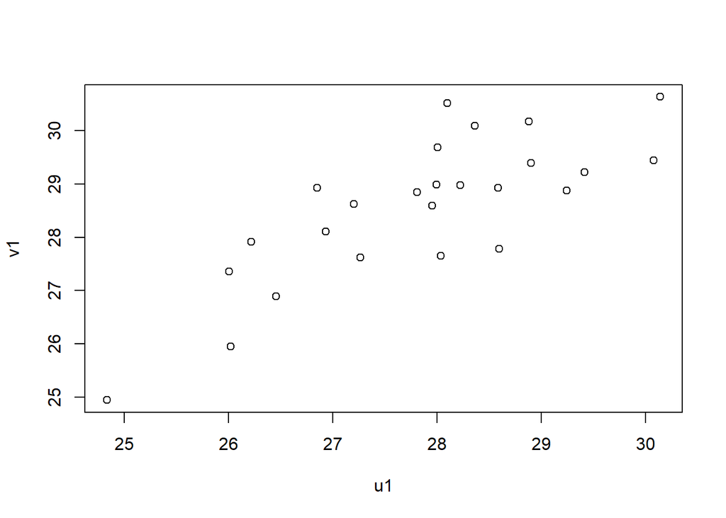

```r
# slope1 <- 1
# slope2 <- 1
#
# u1 <- (slope1 * y.meas$fs_hl) + (slope2 * y.meas$fs_hb)

u1 <- as.matrix(sons.std[, 1:2]) %*% as.matrix(eigen(E1)$vectors[,1])
v1 <- as.matrix(sons.std[, 3:4]) %*% as.matrix(eigen(E2)$vectors[,1])
plot(u1, v1)
```

Correlation for u1, v1

```r
cor(u1, v1)
```

```
##           [,1]
## [1,] 0.7883259
```

#### Interpretation

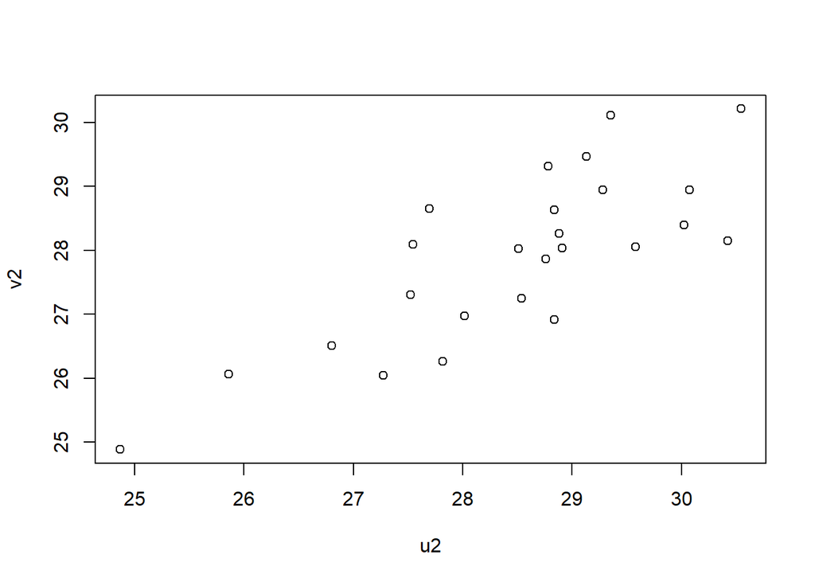

```r
u2 <- as.matrix(sons.std[, 3:4]) %*% as.matrix(eigen(E1)$vectors[,1])
v2 <- as.matrix(sons.std[, 1:2]) %*% as.matrix(eigen(E2)$vectors[,1])
plot(u2, v2)
```

Correlation for u2, v2

```r
cor(u2, v2)
```

```
##           [,1]
## [1,] 0.7882402
```

### c

*Ho:* fs_ss_lth = O, independence between head length between first and second son *Ha:* fs_ss_lth != O, dependence between head length between first and second son

Calculating F stat

```r
k = 2
p = 2
q = 2
n = 25

## formula on page 394
w = n - ( (1/2) * (p + q + 3) )
df1 = (p - k + 1)* (q - k + 1)
t.1 = ( ( (p - k + 1)**2 * (q - k + 1)**2) - 4) /
      ( ( (p - k + 1)**2 + (q - k + 1)**2) - 5)
df2 =(w *  t.1) - ( (1/2) * ( (p - k + 1) * (q - k + 1) + 1) )
F.1 = ( (1 - cor(u1, u2)**(1/t.1)) * df2) / ( (cor(u1, u2)**(1/t.1) ) * df1)
F.1
```

```
##          [,1]
## [1,] 5.508333
```

Find rejection region

```r
qf(.05, df1, df2, lower.tail=FALSE)
```

```
## [1] 4.337667
```

#### Interpretation

*Ho:* fs_ss_bth = O, independence between head breadth between first and second son *Ha:* fs_ss_bth != O, dependence between head breadth between first and second son

Calculating F stat

```r
## use same k, p, q, n, df1, and df2 as above
t.2 = ( ( (p - k + 1)**2 * (q - k + 1)**2) - 4) /
      ( ( (p - k + 1)**2 + (q - k + 1)**2) - 5)
df2 =(w *  t.2) - ( (1/2) * ( (p - k + 1) * (q - k + 1) + 1) )
F.2 = ( (1 - cor(v1, v2)**(1/t.2)) * df2) / ( (cor(v1, v2)**(1/t.2) ) * df1)
F.2
```

```
##          [,1]
## [1,] 5.503333
```

```r
# (repeat for 1 and 2)
```

#### Interpretation

Discussion example

```r
library(CCA)
model <- cc(x.meas, y.meas)
model
```

```
## $cor
## [1] 0.7885079 0.0537397
##
## $names
## $names$Xnames
## [1] "ss_hl" "ss_hb"
##
## $names$Ynames
## [1] "fs_hl" "fs_hb"
##
## $names$ind.names
##  [1] "1"  "2"  "3"  "4"  "5"  "6"  "7"  "8"  "9"  "10" "11" "12" "13" "14" "15"
## [16] "16" "17" "18" "19" "20" "21" "22" "23" "24" "25"
##
##
## $xcoef
##             [,1]      [,2]
## ss_hl -0.5044484 -1.768570
## ss_hb -0.5382877  1.758566
##
## $ycoef
##             [,1]      [,2]
## fs_hl -0.5521896 -1.366374
## fs_hb -0.5215372  1.378365
##
## $scores
## $scores$xscores
##               [,1]        [,2]
##  [1,]  0.583317147 -0.25867829
##  [2,] -1.083576808 -2.29934799
##  [3,] -0.039028038 -0.26723166
##  [4,] -0.189755833 -0.79567548
##  [5,]  1.225925130  0.36425453
##  [6,] -0.631393423 -0.71401655
##  [7,] -0.290241030 -1.14797136
##  [8,] -0.480665628 -0.18557273
##  [9,] -1.444163206  0.23982870
## [10,] -0.299958033 -0.09536041
## [11,] -0.009048238 -0.70546317
## [12,]  0.674085341  1.14622854
```

[output cut: 46 more lines]

```
##
## $scores$corr.Y.xscores
##             [,1]        [,2]
## fs_hl -0.7374817 -0.01901786
## fs_hb -0.7310660  0.02013559
##
## $scores$corr.X.yscores
##             [,1]        [,2]
## ss_hl -0.7539771 -0.01572908
## ss_hb -0.7582663  0.01474027
##
## $scores$corr.Y.yscores
##             [,1]       [,2]
## fs_hl -0.9352877 -0.3538884
## fs_hb -0.9271512  0.3746875
```

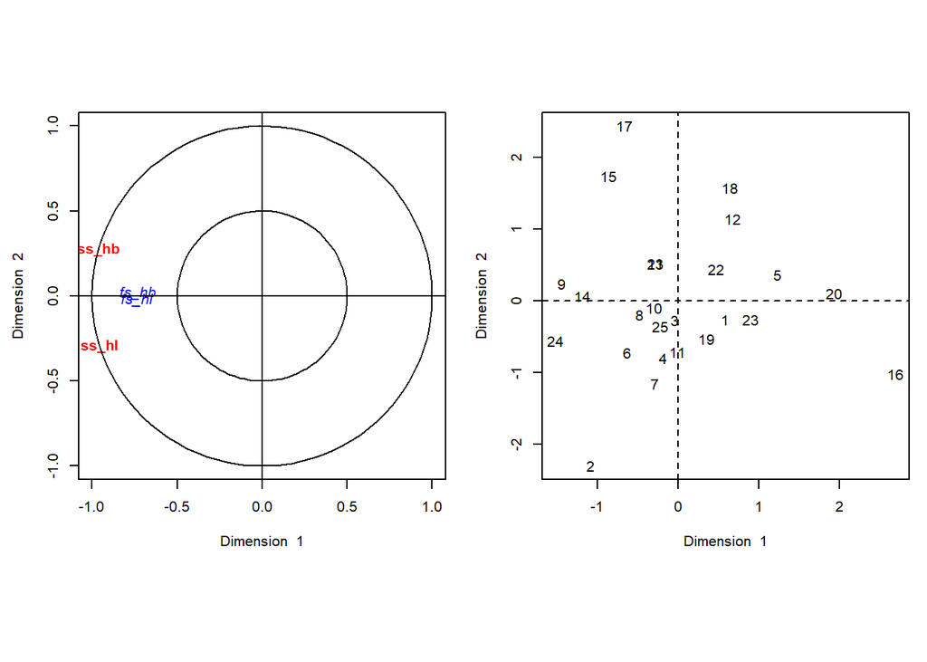

```r
plt.cc(model, var.label = TRUE)
```